# Data Vizualization 2 - Homework 1

Nawal Zehra Hasan

1/16/2022

## Q0. Load the nycflights13 package and check what kind of datasets exist in the package, then create a copy of flights dataset into a data.table object, called flight_data.

| year | month | day | dep_time | sched_dep_time | dep_delay | arr_time | sched_arr_time | arr_delay | carrier | flight | tailnum | origin | dest | air_time | distance | hour | minute | time_hour |
| --- | --- | --- | --- | --- | --- | --- | --- | --- | --- | --- | --- | --- | --- | --- | --- | --- | --- | --- |
| 2013 | 1 | 1 | 517 | 515 | 2 | 830 | 819 | 11 | UA | 1545 | N14228 | EWR | IAH | 227 | 1400 | 5 | 15 | 2013-01-01 05:00:00 |
| 2013 | 1 | 1 | 533 | 529 | 4 | 850 | 830 | 20 | UA | 1714 | N24211 | LGA | IAH | 227 | 1416 | 5 | 29 | 2013-01-01 05:00:00 |
| 2013 | 1 | 1 | 542 | 540 | 2 | 923 | 850 | 33 | AA | 1141 | N619AA | JFK | MIA | 160 | 1089 | 5 | 40 | 2013-01-01 05:00:00 |
| 2013 | 1 | 1 | 544 | 545 | -1 | 1004 | 1022 | -18 | B6 | 725 | N804JB | JFK | BQN | 183 | 1576 | 5 | 45 | 2013-01-01 05:00:00 |
| 2013 | 1 | 1 | 554 | 600 | -6 | 812 | 837 | -25 | DL | 461 | N668DN | LGA | ATL | 116 | 762 | 6 | 0 | 2013-01-01 06:00:00 |
| 2013 | 1 | 1 | 554 | 558 | -4 | 740 | 728 | 12 | UA | 1696 | N39463 | EWR | ORD | 150 | 719 | 5 | 58 | 2013-01-01 05:00:00 |

## Q1. Which destination had the lowest avg arrival delay from LGA with minimum 100 flight to that destination?

| dest | number_of_flights | mean_arrival_delay |
| --- | --- | --- |
| DAY | 391 | -4.947368 |

## Q2. Which destination’s flights were the most on time (avg arrival delay closest to zero) from LGA with minimum 100 flight to that destination?

| dest | number_of_flights | mean_arrival_delay |
| --- | --- | --- |
| MIA | 5781 | -0.0657664 |

## Q3. Who is the manufacturer of the plane, which flights the most to CHS destination?

| tailnum | dest | number_flights | manufacturer |
| --- | --- | --- | --- |
| N713EV | CHS | 22 | BOMBARDIER INC |

## Q4. Which airline (carrier) flow the most by distance?

| carrier | total_distance_flown | name |
| --- | --- | --- |
| UA | 89705524 | United Air Lines Inc. |

## Q5. Plot the monthly number of flights with 20+ mins arrival delay!

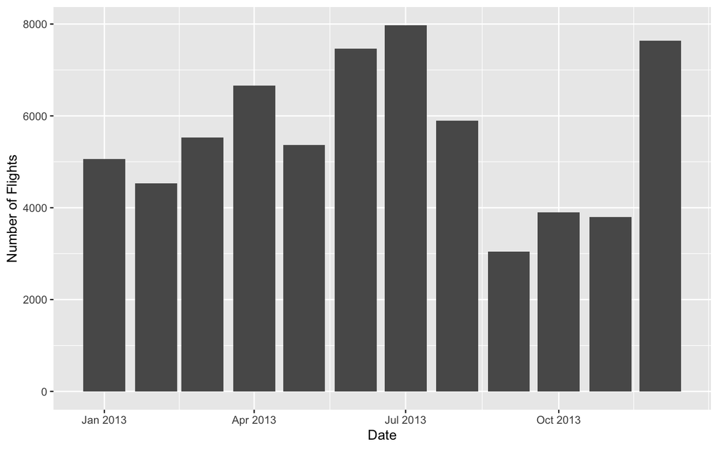

## Q6. Plot the departure delay of flights going to IAH and the related day’s wind speed on a scaterplot! Is there any association between the two variables? Try adding a linear model.

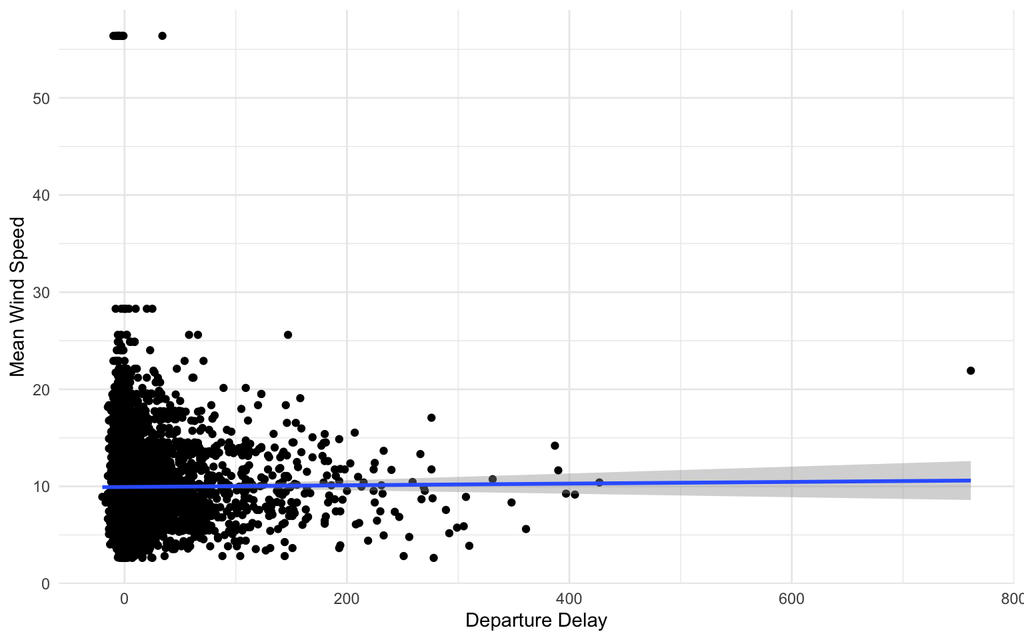

## Q7. Plot the airports as per their geolocation on a world map, by mapping the number flights going to that destination to the size of the symbol!

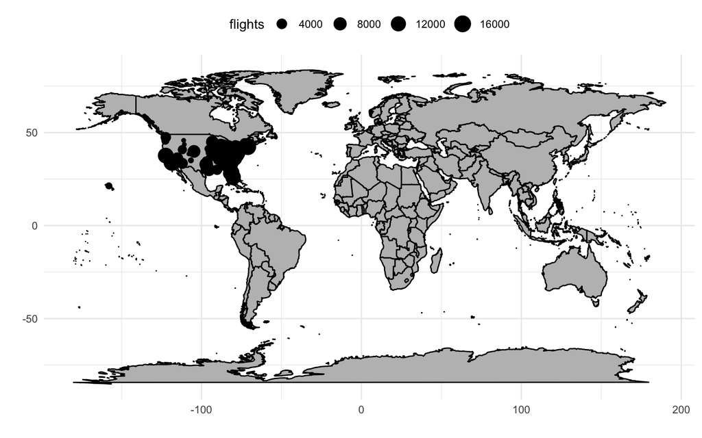